### CIFAR-10 - Object Recognition using Keras with Tensorflow

```
library(plyr)
library(keras)
library(reshape2)
library(ggplot2)
```

先前實作手寫數字的辨識，透過CNN得到不錯的成果，由於MNIST圖像資料為灰階，識別起來比較容易。這次利用[Cifar10 影像資料](https://www.kaggle.com/c/cifar-10)，在色彩、雜訊、角度等複雜度都提升，識別難度比MNIST高許多。Cifar10 資料集提供了50000張彩色圖片的訓練資料，大小為32 * 32，共10個類別(飛機、汽車、鳥、貓、鹿、狗、青蛙、馬、船、卡車)，每一類各5000張。我將隨機利用其中40000筆進行訓練，剩下的10000筆為測試資料。以下為自訂的網路架構，將套用不同的學習率(learning rate)、衰變率(decay)及資料擴增(data augmentation)方法，評估各種models的表現

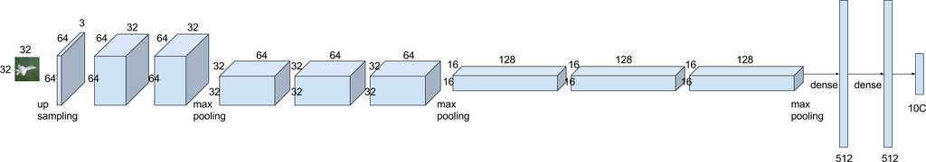

資料集中的trainLabels.csv包含2個欄位(id 和 label)，利用id欄位(圖片檔名)讀入train資料夾中的png檔

```r
dir_path <- 'data/CIFAR-10'

data_labels <- read.csv(file.path(dir_path,'trainLabels.csv'), stringsAsFactors = F)

readIMG <- function(filename_v, folder = 'train') {
  img_folder <- folder
  img_arry <- laply(filename_v, function(filename) {
    img <- image_load(file.path(dir_path, img_folder, filename))
    return(image_to_array(img))
  })
  return(img_arry)
}
# 讀入images
images_data <- readIMG(paste0(data_labels[, 1], '.png'))
```

將label標籤轉成數字、one hot encoding處理

```r
# class 轉數字(從0開始)
num_classes <- 10
images_class <- as.integer(factor(data_labels$label)) - 1

images_class <- to_categorical(images_class, num_classes)

colnames(images_class) <- levels(factor(data_labels$label))
```

隨機取40000筆當作訓練資料、10000筆為測試資料，標準化

```r
set.seed(777)
index <- sample(nrow(images_data), 0.8 * nrow(images_data))

# data
train_data <- images_data[index,,, ] / 255
test_data <- images_data[-index,,, ] / 255

# class
train_class <- images_class[index,]
test_class <- images_class[-index,]
```

由於原圖影像不大(32*32 pixels)，礙於卷積後pooling輸出會更小，首先採up sampling處理，之後再卷積x2、pooling…，資料擴增參數的平移設定為0.2、旋轉角度為10、影像水平翻轉，model批次處理大小固定為128、迭代次數150…

```r
batch_size <- 128
epochs <- 150
kernel_size <- c(3, 3)

trainCNN <- function(lr, decay, data_Aug) {
  model <- keras_model_sequential()

  model %>%
    layer_reshape(target_shape = c(32, 32, 3), input_shape = c(32, 32, 3)) %>%
    layer_upsampling_2d(size = c(2, 2)) %>%
    #64*64

    layer_conv_2d(filter = 32, kernel_size = kernel_size, padding = "same") %>%
    layer_activation("relu") %>%
    layer_batch_normalization() %>%
    layer_conv_2d(filter = 32, kernel_size = kernel_size, padding = "same") %>%
    layer_activation("relu") %>%
    layer_batch_normalization() %>%
    layer_max_pooling_2d(pool_size = c(2,2)) %>%
    layer_batch_normalization() %>%
    layer_dropout(0.25) %>%
    #32*32

    layer_conv_2d(filter = 64, kernel_size = kernel_size, padding = "same") %>%
    layer_activation("relu") %>%
    layer_batch_normalization() %>%
    layer_conv_2d(filter = 64, kernel_size = kernel_size, padding = "same") %>%
    layer_activation("relu") %>%
    layer_batch_normalization() %>%
    layer_conv_2d(filter = 64, kernel_size = kernel_size, padding = "same") %>%
    layer_activation("relu") %>%
    layer_batch_normalization() %>%
    layer_max_pooling_2d(pool_size = c(2,2)) %>%
    layer_batch_normalization() %>%
    layer_dropout(0.25) %>%
    #16*16

    layer_conv_2d(filter = 128, kernel_size = kernel_size, padding = "same") %>%
    layer_activation("relu") %>%
    layer_batch_normalization() %>%
    layer_conv_2d(filter = 128, kernel_size = kernel_size, padding = "same") %>%
    layer_activation("relu") %>%
    layer_batch_normalization() %>%
    layer_max_pooling_2d(pool_size = c(2,2)) %>%
    layer_batch_normalization() %>%
    layer_dropout(0.25) %>%
    #8*8

    layer_flatten() %>%
    layer_dense(units = 512) %>%
    layer_activation("relu") %>%
    layer_dropout(0.5) %>%
    layer_dense(units = 512) %>%
    layer_activation("relu") %>%
    layer_dropout(0.5) %>%
    layer_dense(units = num_classes, activation = 'softmax')

  # Configure
  model %>% compile(
    loss = "categorical_crossentropy",
    optimizer = optimizer_adam(lr = lr, decay = decay),
    metrics = "accuracy"
  )

  result <- NULL

  if(data_Aug) {
    # Data Augmentation
    datagen_train <- image_data_generator(
      width_shift_range = 0.2,
      height_shift_range = 0.2,
      rotation_range = 10,
      horizontal_flip = TRUE,
      rescale = (1. / 1)
    )
    datagen_test <- image_data_generator(rescale = (1. / 1))

    datagen_train %>% fit_image_data_generator(train_data)
    datagen_test %>% fit_image_data_generator(test_data)

    result <- model %>% fit_generator(
      generator = flow_images_from_data(
        train_data,
        train_class,
        datagen_train,
        batch_size = batch_size,
        seed = 777
      ),
      steps_per_epoch = as.integer(dim(train_data)[1] / batch_size),
      epochs = epochs,
      validation_data = flow_images_from_data(
        test_data,
        test_class,
        datagen_test,
        batch_size = batch_size,
        seed = 777
      ),
      validation_steps = as.integer(dim(test_data)[1] / batch_size)
    )
  } else{
    result <- model %>% fit(
      train_data,
      train_class,
      batch_size = batch_size,
      epochs = epochs,
      validation_data = list(test_data, test_class),
      shuffle = TRUE
    )
  }

  return(result)
}
```

學習率自訂0.002和0.001，衰變率自訂0和0.0001，資料擴增處理與否，共8種參數組合分別進行訓練

```r
# grid
expand.grid(lr = c(0.002, 0.001), decay = c(0, 1e-4), data_Aug = c(TRUE, FALSE))
```

```
##      lr decay data_Aug
## 1 0.002 0e+00     TRUE
## 2 0.001 0e+00     TRUE
## 3 0.002 1e-04     TRUE
## 4 0.001 1e-04     TRUE
## 5 0.002 0e+00    FALSE
## 6 0.001 0e+00    FALSE
## 7 0.002 1e-04    FALSE
## 8 0.001 1e-04    FALSE
```

以下為這8種models的accuracy表現，1 ~ 4有使用資料擴增，5 ~ 8 則沒有使用，可以看出上排有使用的accuracy明顯較高，沒有over fitting，而3、4、7、8有使用衰變率的情形下曲線較平穩

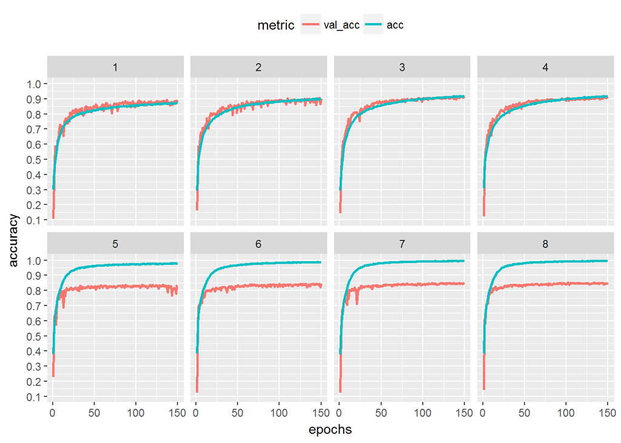

loss值的表現也是1 ~ 4有使用資料擴增者較好

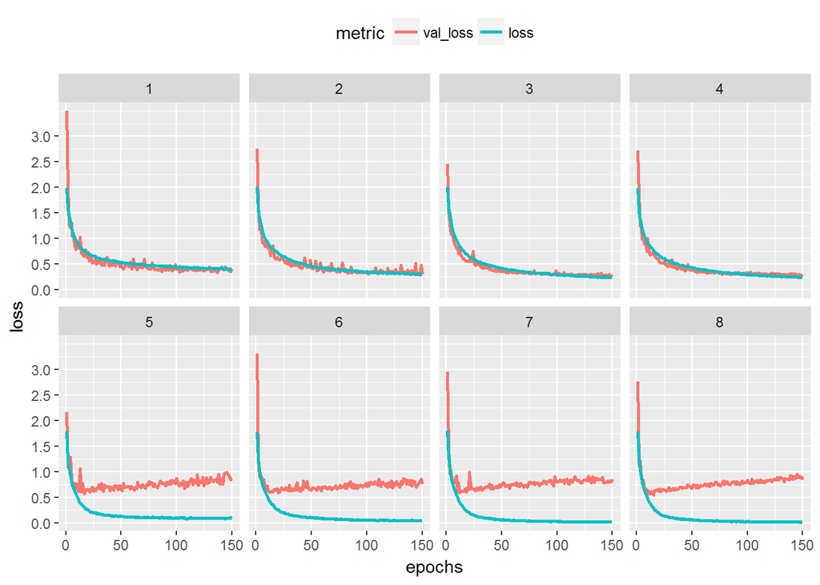

accuracy 和 loss 前5者，以 model 3居多，model 4則有一次，其中以model 3的第146 epoch表現最佳，accuracy為0.9178485，loss為0.2635953

```r
# acc top 5
head(arrange(subset(result_df, subset=(metric=='val_acc')), desc(value)), 5)
```

```
##   model epoch     value  metric
## 1     3   146 0.9178485 val_acc
## 2     3   149 0.9123784 val_acc
## 3     4   135 0.9122771 val_acc
## 4     3   139 0.9116694 val_acc
## 5     3   145 0.9107577 val_acc
```

```r
# loss top 5
head(arrange(subset(result_df, subset=(metric=='val_loss')), value), 5)
```

```
##   model epoch     value   metric
## 1     3   146 0.2635953 val_loss
## 2     3   145 0.2709962 val_loss
## 3     3   134 0.2748247 val_loss
## 4     4   135 0.2754903 val_loss
## 5     3   149 0.2770633 val_loss
```

基於以上的表現，使用model 3的參數設定值(lr = 0.002, decay = 0.0001, data_Aug = TRUE)，網路架構除了卷積filter增加2倍，其餘設定不變，重新訓練後(tune model)結果如下。測試的accuracy 前5者有3次超越0.92，loss值前5者則落在0.286 ~ 0.291之間

```
##   epoch     value  metric
## 1   146 0.9250405 val_acc
## 2   132 0.9206848 val_acc
## 3   141 0.9204822 val_acc
## 4   145 0.9180511 val_acc
## 5   149 0.9177472 val_acc
```

```
##   epoch     value   metric
## 1   101 0.2862348 val_loss
## 2   110 0.2886686 val_loss
## 3    77 0.2900849 val_loss
## 4   116 0.2904058 val_loss
## 5    97 0.2917051 val_loss
```

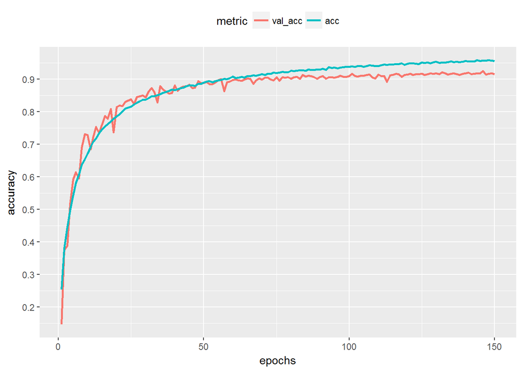

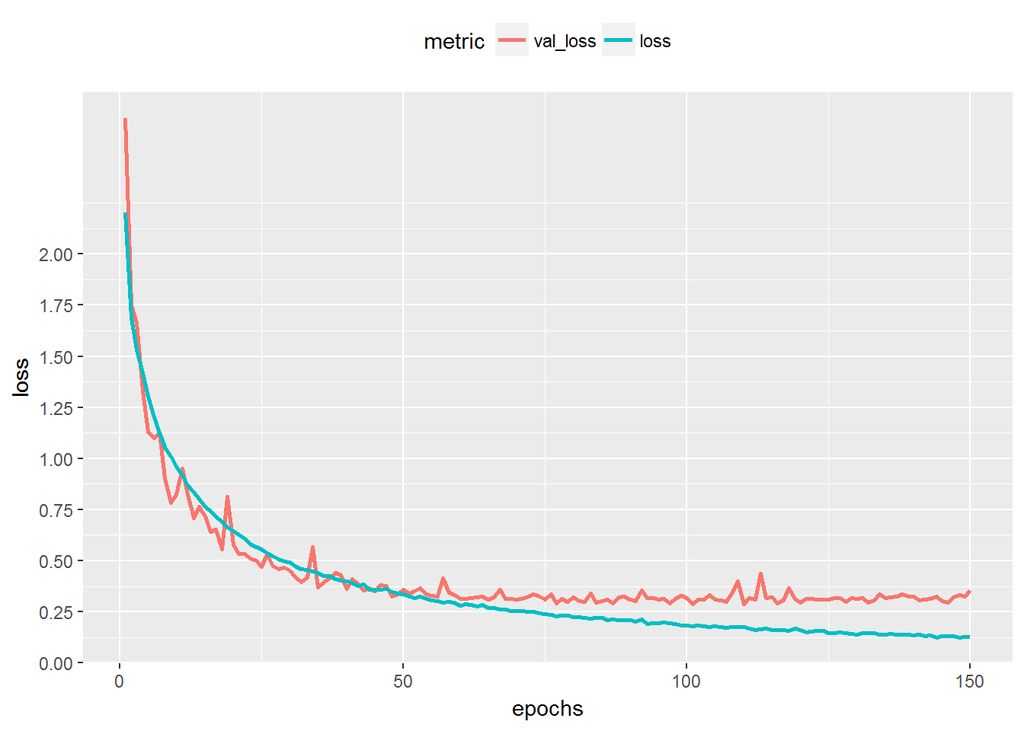

以下是 tune model 預測label和實際測試資料label矩陣，從中約略可看出幾乎預測正確都大於900以上，表示這些準確度應該都有大於0.9以上，除了貓(cat)表現略差，辨識正確者只有785，且容易預測誤判為狗(dog)有141筆。不過狗誤判為貓的錯誤則明顯少非常多，只有30例，此外，鳥誤判為飛機者有37例，其它誤判筆都少於30以下

```
##             test_label
## pred_label   airplane automobile bird cat deer dog frog horse ship truck
##   airplane        938          6   37  10    9   5    5     3   23    17
##   automobile        7        968    2   4    0   1    1     0    8    24
##   bird             11          3  907  18   25  17   25     2    5     1
##   cat               4          1   20 785   13  30   18    11    3     1
##   deer              4          1   16  18  911  15   12    12    3     0
##   dog               1          1   20 141   21 903   10    10    1     0
##   frog              2          1   16  16    7   5  904     3    3     3
##   horse             6          1    8   8   10  17    0   936    0     1
##   ship             10          3    2   2    2   3    0     0  937     4
##   truck             8         16    2   6    1   2    0     4   11   972
```

#### **Summary**

這次實作CNN在彩色影像於分類任務上，使用三個參數調整(八種組合)，從表現上來看，透過資料擴增(data augmentation)和衰變率(decay)的設定，不但提高了辨識的準確度，也減少了overfitting現象。最後，我利用組合中表現最佳的參數設定(lr = 0.002, decay = 0.0001, data_Aug = TRUE)，再增加網路架構中卷積的filter數量，測試的accuracy可以達到0.92，其網路架構參數設定如下

```
## ___________________________________________________________________________
## Layer (type)                     Output Shape                  Param #
## ===========================================================================
## reshape_18 (Reshape)             (None, 32, 32, 3)             0
## ___________________________________________________________________________
## up_sampling2d_24 (UpSampling2D)  (None, 64, 64, 3)             0
## ___________________________________________________________________________
## conv2d_148 (Conv2D)              (None, 64, 64, 64)            1792
## ___________________________________________________________________________
## activation_186 (Activation)      (None, 64, 64, 64)            0
## ___________________________________________________________________________
## batch_normalization_208 (BatchNo (None, 64, 64, 64)            256
## ___________________________________________________________________________
## conv2d_149 (Conv2D)              (None, 64, 64, 64)            36928
## ___________________________________________________________________________
## activation_187 (Activation)      (None, 64, 64, 64)            0
## ___________________________________________________________________________
## batch_normalization_209 (BatchNo (None, 64, 64, 64)            256
## ___________________________________________________________________________
## max_pooling2d_60 (MaxPooling2D)  (None, 32, 32, 64)            0
## ___________________________________________________________________________
## batch_normalization_210 (BatchNo (None, 32, 32, 64)            256
## ___________________________________________________________________________
## dropout_98 (Dropout)             (None, 32, 32, 64)            0
## ___________________________________________________________________________
## conv2d_150 (Conv2D)              (None, 32, 32, 128)           73856
## ___________________________________________________________________________
## activation_188 (Activation)      (None, 32, 32, 128)           0
## ___________________________________________________________________________
## batch_normalization_211 (BatchNo (None, 32, 32, 128)           512
## ___________________________________________________________________________
## conv2d_151 (Conv2D)              (None, 32, 32, 128)           147584
## ___________________________________________________________________________
## activation_189 (Activation)      (None, 32, 32, 128)           0
## ___________________________________________________________________________
## batch_normalization_212 (BatchNo (None, 32, 32, 128)           512
## ___________________________________________________________________________
## conv2d_152 (Conv2D)              (None, 32, 32, 128)           147584
## ___________________________________________________________________________
## activation_190 (Activation)      (None, 32, 32, 128)           0
```

[output cut: 32 more lines]

```
## ___________________________________________________________________________
## dropout_101 (Dropout)            (None, 512)                   0
## ___________________________________________________________________________
## dense_59 (Dense)                 (None, 512)                   262656
## ___________________________________________________________________________
## activation_194 (Activation)      (None, 512)                   0
## ___________________________________________________________________________
## dropout_102 (Dropout)            (None, 512)                   0
## ___________________________________________________________________________
## dense_60 (Dense)                 (None, 10)                    5130
## ===========================================================================
## Total params: 9,955,786
## Trainable params: 9,952,842
## Non-trainable params: 2,944
## ___________________________________________________________________________
```